# Topic 3 DQ 1

"Probability is the foundation of statistical inference and decision-making. Discuss the role of probability theory in making decisions under uncertainty. How can probability be used to model and analyze real-world problems in fields such as finance, engineering, and social sciences? Provide at least two examples of applications of probability theory in your discussion. How can Python be used to implement useful tools in this context?"

Probability theory plays an important role in making decisions under uncertainty by providing a mathematical framework for quantifying the likelihood of various outcomes. This quantification allows people and organizations to make informed decisions based on the likelihood of different events, rather than relying on only intuition or deterministic models. In fields such as finance, engineering, and social sciences, probability theory is used to model uncertainty, assess risks, and guide decision-making processes.

### Role of Probability Theory in Decision-Making

Understanding Uncertainty: Probability theory helps quantify the uncertainty associated with various outcomes, enabling decision-makers to assess risks and potential benefits more accurately.

Modeling Complex Systems: It allows for the modeling of complex systems where outcomes are uncertain, providing insights into the behavior of such systems under different scenarios.

Improving Decisions: By evaluating the probabilities of different outcomes, decision-makers can optimize their decisions to maximize expected benefits or minimize potential losses.

### Applications of Probability Theory

Finance: In finance, probability theory is used extensively in portfolio management and financial modeling. For example, the Modern Portfolio Theory (MPT) uses probability distributions to balance the trade-off between risk and return in investment portfolios. Another application is in the pricing of options and other derivatives, where models like the Black-Scholes formula use probability theory to determine the fair value of these financial instruments based on the likelihood of different price movements.

Engineering: In engineering, reliability engineering uses probability theory to predict the failure rates of systems and components. This allows engineers to design more reliable and robust systems. For example, the probability of component failures can be modeled using distributions such as the exponential or Weibull distributions, enabling engineers to predict the lifespan of components and schedule maintenance or replacements to minimize downtime.

Social Sciences: In social sciences, probability theory is used in statistical inference to draw conclusions about populations based on sample data. For instance, opinion polls use probability sampling techniques to estimate the opinions or behaviors of a larger population, providing insights into public opinion trends or voting intentions with a quantifiable margin of error.

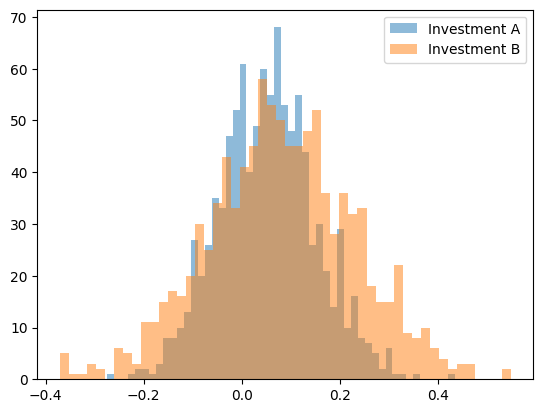

```python
#Python, with libraries like NumPy and matplotlib, is a powerful tool for implementing probability models and simulations.

import numpy as np
import matplotlib.pyplot as plt

# Simulate returns for two investments
np.random.seed(42)
returns_A = np.random.normal(0.05, 0.1, 1000)
returns_B = np.random.normal(0.07, 0.15, 1000)

# Calculate expected returns and volatility
expected_return_A = np.mean(returns_A)
volatility_A = np.std(returns_A)
expected_return_B = np.mean(returns_B)
volatility_B = np.std(returns_B)

# Plot the distributions
plt.hist(returns_A, bins=50, alpha=0.5, label='Investment A')
plt.hist(returns_B, bins=50, alpha=0.5, label='Investment B')
plt.legend()
plt.show()
```

The histogram compares the distribution of returns for Investment A and Investment B. Both investments show a roughly bell-shaped distribution, but Investment A appears to have a tighter clustering around the mean and less variance than Investment B. Investment B shows a broader spread of returns, indicating higher variability or risk. The overlap suggests similar performance ranges, but the specific details of skewness, kurtosis, and the exact range of returns would further inform their risk profiles.

### Sources

Manoharan, V. N. (2020). Lecture 1: Introduction to Statistical Inference and Probability Theory. Retrieved from https://canvas.harvard.edu/courses/79266/files/11537709/download?verifier=SnZbv3iuqoMwKH0A7OdCX3EsH8Yuif8GUe0i0pqx&wrap=1

Rogel-Salazar, J. (2023). Definitely Maybe: Probability and Distributions. In Statistics and data visualisation with Python (1st ed.). CRC Press.